# Data Reading and Preprocessing

X

2024-01-28

## 0.1 Set up libraries

```r
library(tidyverse)
library(ggplot2)
library(stringr)
#library(sjstats) # TE: This library is not used
```

## 0.2 Read data

Read Western data

```r
d1<-read.csv('MusicFinal.csv',skip = 0,header = TRUE)
d2<-read.csv('Bs1.csv',skip = 0,header = TRUE)
d3<-read.csv('BsFinal.csv',skip = 0,header = TRUE)
d4<-read.csv('Uni.csv',skip = 0,header = TRUE)
d5<-read.csv('Final_stretch_December 30, 2023_12.09.csv',skip = 0,header = TRUE)

d1<-d1[3:nrow(d1),]# delete two first rows (metadata)
d2<-d2[3:nrow(d1),]# TE: add this well
d3<-d3[3:nrow(d1),]
d4<-d4[3:nrow(d1),]
d5<-d5[3:nrow(d1),]
dw <- rbind(d1, d2, d3, d4, d5)
#df<-d[3:nrow(d),]# TE: removed
print(dim(dw))
```

```
## [1] 362  72
```

Read Indian data

```r
d6<-read.csv('For Indians_RhythmLearning_Study1_January 28, 2024_12.21.csv',skip = 0,header = TRUE)
d6<-d6[3:nrow(d6),]# delete two first rows (metadata)
print(dim(d6))
```

```
## [1] 120  83
```

## 0.3 Filter data

Western data

```r
dw <- dplyr::filter(dw,as.numeric(Progress) > 96)
dw <- dplyr::filter(dw,as.numeric(Duration..in.seconds.)>4*60) # 4 mins
print(nrow(dw))
```

```
## [1] 81
```

Indian data

```r
di<- dplyr::filter(d6,as.numeric(Progress) > 96)
di <- dplyr::filter(di,as.numeric(Duration..in.seconds.)>4*60) # 4 mins
print(nrow(di))
```

```
## [1] 76
```

## 0.4 Reporting age and sd of the dataset

western data

```r
numeric_age <- as.numeric(dw$Q_Age)
mean_age <- mean(numeric_age, na.rm = TRUE) #age of participants
sd_age <- sd(numeric_age, na.rm = TRUE) #sd for age
print(paste('Mean age:',round(mean_age,2), 'SD:',round(sd_age)))
```

```
## [1] "Mean age: 27.85 SD: 10"
```

Indian data

```r
numeric_age2 <- as.numeric(di$Q_Age)
mean_age2 <- mean(numeric_age2, na.rm = TRUE) #age of participants
sd_age2 <- sd(numeric_age2, na.rm = TRUE) #sd for age
print(paste('Mean age:',round(mean_age2,2), 'SD:',round(sd_age)))
```

```
## [1] "Mean age: 30.42 SD: 10"
```

## 0.5 Removing Indian participants from Non-Indian data

```r
dw$Familiarity <- ifelse(dw$Q_Ethnicity %in% c('Indian', 'Asian - Indian', 'Asian -Indian','Asian- Indian','Asian-Indian','Indian ', 'Asian - Indian '), 'Indian Ethnicity', 'Non-Indian Ethnicity')
Sf<-summarise(group_by(dw,Familiarity),n=n()) # count
knitr::kable(Sf)
```

| Familiarity | n |
| --- | --- |
| Indian Ethnicity | 17 |
| Non-Indian Ethnicity | 64 |

```r
#(optional)writing Indian Participants seperately
#subsetind_df <- df[df$Familiarity == 'Indian Ethnicity', ]
# Write the subset to a CSV file
#write.csv(subsetind_df, file = "indian_ethnicity.csv", row.names = FALSE)
```

##Group into musicians and non-musicians Western data

```r
dw$Musicianship <- ifelse(dw$Q_Musicianship %in% c('Amateur musician', 'Serious amateur musician','Semiprofessional musician', 'Professional musician'), 'Musician', 'Non-Musician')
dw<-drop_na(dw) # drop missing observations
Sm<-summarise(group_by(dw,Musicianship,Familiarity),n=n()) # count
knitr::kable(Sm)
```

| Musicianship | Familiarity | n |
| --- | --- | --- |
| Musician | Indian Ethnicity | 10 |
| Musician | Non-Indian Ethnicity | 34 |
| Non-Musician | Indian Ethnicity | 7 |
| Non-Musician | Non-Indian Ethnicity | 30 |

```r
#deleting Indian participants from western data
dw1 <- dw[!(dw$Musicianship == 'Musician' & dw$Familiarity == 'Indian Ethnicity') & !(dw$Musicianship == 'Non-Musician' & dw$Familiarity == 'Indian Ethnicity') , ]
Sfilter<-summarise(group_by(dw1,Musicianship,Familiarity),n=n()) # count
knitr::kable(Sfilter)
```

| Musicianship | Familiarity | n |
| --- | --- | --- |
| Musician | Non-Indian Ethnicity | 34 |
| Non-Musician | Non-Indian Ethnicity | 30 |

Indian data

```r
# Create a new column 'Musicianship' based on Score
di$Musicianship <- ifelse(di$ScoreFam >= 4, 'Musician', ifelse(is.na(di$ScoreFam) | di$ScoreFam < 4, 'Non-Musician', NA))
Sm2<-summarise(group_by(di,Musicianship),n=n()) # count
knitr::kable(Sm2)
```

| Musicianship | n |
| --- | --- |
| Musician | 32 |
| Non-Musician | 44 |

##Arranging Columns

```r
#western data
dw2 <- dplyr::select(dw1,ResponseId,Musicianship,Familiarity, starts_with('Base_'), starts_with('Test_'))
dw_long <- tidyr::pivot_longer(dw2,ends_with('_1'))#changing to long

#indian data
di2 <- dplyr::select(di,ResponseId,Musicianship,starts_with('Base_'), starts_with('Test_'))
di_long <- tidyr::pivot_longer(di2,ends_with('_1'))#changing to long
```

## 0.6 Code the factor names and rating values

Western data

```r
dw_long$condition <- str_split_i(dw_long$name,'_',1)#splittig condition Baseline/Testing
#print (df_long$condition)
dw_long$pattern <- str_split_i(dw_long$name,'_',2)#splittig pattern Teental/Rupak
#print (df_long$pattern)
dw_long$type <- str_split_i(dw_long$name,'_',3) #splitting type of rhythm sd,sp,natural,basic,complex
#print (df_long$type)

table(dw_long$condition)
```

```
##
## Base Test
##  640  768
```

```r
table(dw_long$pattern)
```

```
##
##   Rupak Teental
##     704     704
```

```r
table(dw_long$type)
```

```
##
##   Basic Complex  Naturl Naturl2 Naturll     sd1     sp1
##     256     256     256      64      64     256     256
```

```r
table(dw_long$type,dw_long$condition)
```

```
##
##           Base Test
##   Basic    128  128
##   Complex  128  128
##   Naturl   128  128
##   Naturl2    0   64
##   Naturll    0   64
##   sd1      128  128
##   sp1      128  128
```

Indian data

```r
di_long$condition <- str_split_i(di_long$name,'_',1)#splittig condition Baseline/Testing
#print (df_long$condition)
di_long$pattern <- str_split_i(di_long$name,'_',2)#splittig pattern Teental/Rupak
#print (df_long$pattern)
di_long$type <- str_split_i(di_long$name,'_',3) #splitting type of rhythm sd,sp,natural,basic,complex
#print (df_long$type)

# TE adds these reports just to check what is in the data (from previous code)
table(di_long$condition)
```

```
##
## Base Test
##  760  912
```

```r
table(di_long$pattern)
```

```
##
##   Rupak Teental
##     836     836
```

```r
table(di_long$type)
```

```
##
##   Basic Complex  Naturl Naturl2 Naturll     sd1     sp1
##     304     304     304      76      76     304     304
```

```r
table(di_long$type,di_long$condition)
```

```
##
##           Base Test
##   Basic    152  152
##   Complex  152  152
##   Naturl   152  152
##   Naturl2    0   76
##   Naturll    0   76
##   sd1      152  152
##   sp1      152  152
```

#Converting Strings to Numbers Western data

```r
table(dw_long$value)# since the ratings are string, not numbers, convert them
```

```
##
##                     Extremely Similar Moderately Similar Not at all similar
##                704                129                104                 26
##        Not Similar            Similar   Slightly Similar       Very Similar
##                 62                137                102                144
```

```r
dw_long$value_c <- factor(dw_long$value,levels = rev(c("Extremely Similar","Very Similar","Similar","Moderately Similar","Slightly Similar","Not Similar","Not at all similar")))
table(dw_long$value_c)
```

```
##
## Not at all similar        Not Similar   Slightly Similar Moderately Similar
##                 26                 62                102                104
##            Similar       Very Similar  Extremely Similar
##                137                144                129
```

```r
dw_long$similarity <- as.numeric(dw_long$value_c) # as numeric
table(dw_long$similarity)
```

```
##
##   1   2   3   4   5   6   7
##  26  62 102 104 137 144 129
```

Indian data

```r
table(di_long$value)# since the ratings are string, not numbers, convert them
```

```
##
##                     Extremely Similar Moderately Similar Not at all similar
##                842                155                113                 39
##        Not Similar            Similar   Slightly Similar       Very Similar
##                101                128                137                157
```

```r
di_long$value_c <- factor(di_long$value,levels = rev(c("Extremely Similar","Very Similar","Similar","Moderately Similar","Slightly Similar","Not Similar","Not at all similar")))
table(di_long$value_c)
```

```
##
## Not at all similar        Not Similar   Slightly Similar Moderately Similar
##                 39                101                137                113
##            Similar       Very Similar  Extremely Similar
##                128                157                155
```

```r
di_long$similarity <- as.numeric(di_long$value_c) # as numeric
table(di_long$similarity)
```

```
##
##   1   2   3   4   5   6   7
##  39 101 137 113 128 157 155
```

#Checking the number of observations Western data

```r
dw_long<-drop_na(dw_long) # drop missing observations
S<-summarise(group_by(dw_long,pattern,condition),n=n()) # count
knitr::kable(S)
```

| pattern | condition | n |
| --- | --- | --- |
| Rupak | Base | 165 |
| Rupak | Test | 198 |
| Teental | Base | 155 |
| Teental | Test | 186 |

Indian data

```r
di_long<-drop_na(di_long) # drop missing observations
S2<-summarise(group_by(di_long,pattern,condition),n=n()) # count
knitr::kable(S2)
```

| pattern | condition | n |
| --- | --- | --- |
| Rupak | Base | 215 |
| Rupak | Test | 252 |
| Teental | Base | 165 |
| Teental | Test | 198 |

##writing both data seperately for later analysis

```r
# Write the subset to a CSV file
write.csv(dw_long, file = "Westerndata.csv", row.names = FALSE)
write.csv(di_long, file = "Indiandata.csv", row.names = FALSE)
```

#quality control: Western data

##quality control question

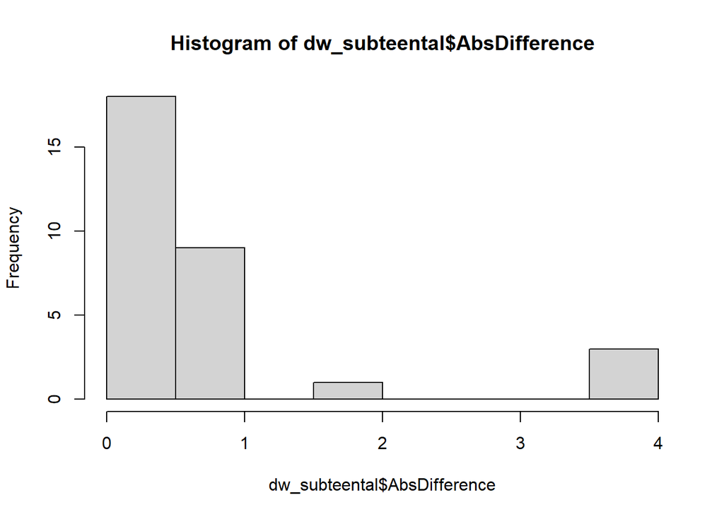

```r
#Explanation of naming in experiment: Naturl= Natural for both Teental and Rupak, Naturll= Test for Teental, Naturl2= Test for Rupak

# Subset for 'Teental' and 'Rupak'
dw_subset_teental <- dw_long[(dw_long$pattern == 'Teental'& dw_long$condition=='Test' & (dw_long$type == 'Naturl' | dw_long$type == 'Naturll')),]
dw_subset_rupak <- dw_long[(dw_long$pattern == 'Rupak'& dw_long$condition=='Test' & (dw_long$type == 'Naturl' | dw_long$type == 'Naturl2')), ]

dw_subteental <- dw_subset_teental %>%
  filter(type %in% c('Naturll', 'Naturl')) %>%
  group_by(ResponseId) %>%
  summarise(AbsDifference = abs(diff(similarity[type %in% c('Naturl', 'Naturll')])))

# Direction of the difference is meaningless, so use absolute instead

dw_subrupak <- dw_subset_rupak %>%
  filter(type %in% c('Naturl', 'Naturl2')) %>%
  group_by(ResponseId) %>%
  summarise(AbsDifference = abs(diff(similarity[type %in% c('Naturl', 'Naturl2')])))

#plotting teental
hist(dw_subteental$AbsDifference)
```

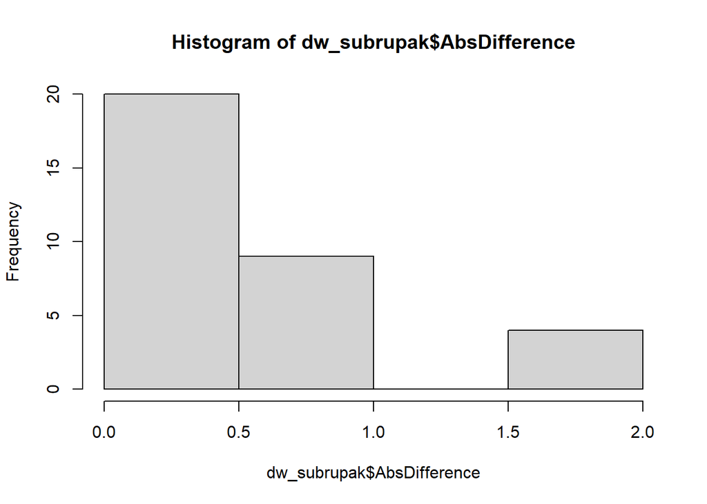

```r
#plotting rupak
hist(dw_subrupak$AbsDifference)
```

```r
dw_subrupak$ResponseId[dw_subrupak$AbsDifference >2]# also display the id of the person who is inconsistent
```

```
## character(0)
```

```r
dw_subteental$ResponseId[dw_subteental$AbsDifference >2]# also display the id of the person
```

```
## [1] "R_2Uax5iSyFsc52pZ" "R_3kpjZD1SAq9rBt8" "R_3lYS6mLft5j6zOW"
```

## 0.7 Cronbach’s alpha

western musicians

```r
library(psych)
dwmus <- dw_long[dw_long$Musicianship=='Musician' & dw_long$type %in% c('sd1', 'sp1', 'Basic', 'Naturl', 'Complex'),]
U <- unique(dwmus$type)
S <- unique(dwmus$ResponseId)
alpha <- matrix(0, 1, length(U))

TMP <- NULL
for (k in 1:length(S)) {
  B <- dplyr::filter(dwmus, ResponseId == S[k])
  TMP <- cbind(TMP, as.numeric(B$similarity))
}
colnames(TMP) <- S
a <- suppressMessages(suppressWarnings(psych::alpha(TMP, check.keys = FALSE, warnings = FALSE)))
Alpha <- a$total$raw_alpha

# display individual ones
print(a$item.stats$r.cor)
```

```
##  [1] 0.597136629 0.194071879 0.351574087 0.427550521 0.259046668 0.003995324
##  [7] 0.632730487 0.757018671 0.701082272 0.595006466 0.165177460 0.317749727
## [13] 0.626874936 0.664014163 0.828219863 0.679904329 0.601818023 0.220461989
## [19] 0.869264381 0.828279966 0.742905538 0.678485132 0.462804715 0.937370927
## [25] 0.766919593 0.563332824 0.800427675 0.735586821 0.374042614 0.809841438
## [31] 0.491454803 0.342895193 0.665985121 0.596987727
```

```r
colnames(TMP)[a$item.stats$r.cor < 0] # anybody under 0?
```

```
## character(0)
```

```r
colnames(TMP)[a$item.stats$r.cor < 0.7]
```

```
##  [1] "R_2WDzA7IgRJPp3JF" "R_1Fxdb0XA8qhREvT" "R_3qVcIjjGEv9IoNF"
##  [4] "R_2TYGG06vV3ADVbZ" "R_Y37Skr4yM3t1fwt" "R_1EYSU7KE5Mkoz2g"
##  [7] "R_1ouMNfVWF83qtdH" "R_10UDVIwF9NXl8sv" "R_3gSH5akGiXx7BPZ"
## [10] "R_1LjMGVBrxWNuyXV" "R_3oGzEIXg7YNdJp9" "R_AdEhyNIxitZncAx"
## [13] "R_1jv4ivmLI9jJMMP" "R_2S2I0qKA25s0ZyJ" "R_1IuEF0vfCb2DTk4"
## [16] "R_NXOHucrI0whretb" "R_2rSior2YdtMAaR4" "R_A7GRdm6HqjwYb6x"
## [19] "R_32Wyg5qidqCL2Qz" "R_5I6IK57oIweYOqv" "R_8g2tztS4LgPsddn"
## [22] "R_5Ka3NX81a3m7dW2" "R_4J3CL0l2g5gYG3w"
```

NA: None of the participants with alpha <0.7 match with the one in quality control question test above, How do I remove it?

Western non-musicians

```r
dwmus <- dw_long[dw_long$Musicianship=='Non-Musician' & dw_long$type %in% c('sd1', 'sp1', 'Basic', 'Naturl', 'Complex'),]
U <- unique(dwmus$type)
S <- unique(dwmus$ResponseId)
alpha <- matrix(0, 1, length(U))

TMP <- NULL
for (k in 1:length(S)) {
  B <- dplyr::filter(dwmus, ResponseId == S[k])
  TMP <- cbind(TMP, as.numeric(B$similarity))
}
colnames(TMP) <- S
a <- suppressMessages(suppressWarnings(psych::alpha(TMP, check.keys = FALSE, warnings = FALSE)))
Alpha <- a$total$raw_alpha

# display individual ones
a$item.stats$r.cor
```

```
##  [1] 0.36379737 0.73937870 0.46728719 0.32820593 0.62119071 0.40609219
##  [7] 0.59115673 0.42786798 0.39969403 0.06316643 0.80438135 0.57422633
## [13] 0.43358992 0.14047403 0.59926112 0.64325012 0.01305085 0.58848522
## [19] 0.80132415 0.01477426 0.84568586 0.79756197 0.68094241 0.28344638
## [25] 0.40326705 0.68594668 0.53042004 0.61883172 0.61414723 0.57942090
```

```r
colnames(TMP)[a$item.stats$r.cor < 0]
```

```
## character(0)
```

```r
colnames(TMP)[a$item.stats$r.cor < 0.7]
```

```
##  [1] "R_3lYS6mLft5j6zOW" "R_4Z5P0d7Y9rcmyxb" "R_WvOJJzbxYCk7Oc9"
##  [4] "R_1BUUZ8KJd6TXI3o" "R_5p6LcboySRm53CF" "R_AyrIl6TkbcwWOu5"
##  [7] "R_2uyZsFY8RBNAvql" "R_01wjQZUqbwFVBe1" "R_ZyJzf6j0MaiPnIR"
## [10] "R_3Pe4w1M2aN8Ed6J" "R_1N4YMozXjmlBYdz" "R_3nr2LY85Sx5O808"
## [13] "R_2vd08DH1Mgfo39M" "R_1I9FOkdioQtiBv2" "R_3GwbgXS7CGpW4iT"
## [16] "R_2f0VTJ7FWtRHfNk" "R_2Uax5iSyFsc52pZ" "R_3ho7aw3U63ysaYj"
## [19] "R_3kpjZD1SAq9rBt8" "R_51Wy22zfHAqkXaQ" "R_4EFgEqNZjJlpGAe"
## [22] "R_2nTQvIdgeEcQLDj" "R_4eEOZSX7g4iyVGI" "R_264h04EJbLktzU4"
## [25] "R_5fJ1WZNAFVTSfhy"
```

NA: all three participants (R_2Uax5iSyFsc52pZ, R_3kpjZD1SAq9rBt8, R_3lYS6mLft5j6zOW) participants with alpha <0.7 match with the one in quality control question test above, should we remove the data?

#quality control: Indian data ##quality control question

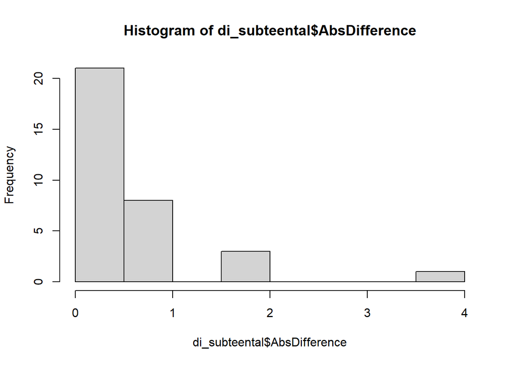

```r
#Explanation of naming in experiment: Naturl= Natural for both Teental and Rupak, Naturll= Test for Teental, Naturl2= Test for Rupak

# Subset for 'Teental' and 'Rupak'
di_subset_teental <- di_long[(di_long$pattern == 'Teental'& di_long$condition=='Test' & (di_long$type == 'Naturl' | di_long$type == 'Naturll')),]
di_subset_rupak <- di_long[(di_long$pattern == 'Rupak'& di_long$condition=='Test' & (di_long$type == 'Naturl' | di_long$type == 'Naturl2')), ]

di_subteental <- di_subset_teental %>%
  filter(type %in% c('Naturll', 'Naturl')) %>%
  group_by(ResponseId) %>%
  summarise(AbsDifference = abs(diff(similarity[type %in% c('Naturl', 'Naturll')])))

# Direction of the difference is meaningless, so use absolute instead

di_subrupak <- di_subset_rupak %>%
  filter(type %in% c('Naturl', 'Naturl2')) %>%
  group_by(ResponseId) %>%
  summarise(AbsDifference = abs(diff(similarity[type %in% c('Naturl', 'Naturl2')])))

#plotting teental
hist(di_subteental$AbsDifference)
```

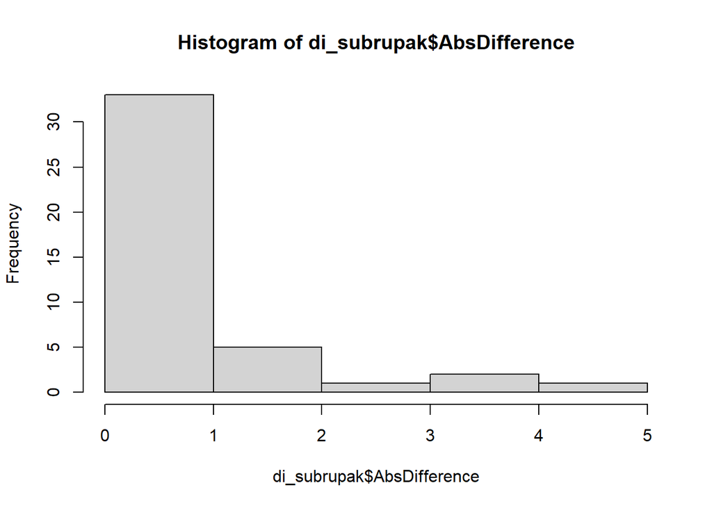

```r
#plotting rupak
hist(di_subrupak$AbsDifference)
```

```r
di_subrupak$ResponseId[di_subrupak$AbsDifference >2]# also display the id of the person who is inconsistent
```

```
## [1] "R_4I4TMipFxznklgt" "R_4PhKWMzINpHFoVy" "R_4Y9utJ6hhxLFuDy"
## [4] "R_4qsOSprsTyIzn7e"
```

```r
di_subteental$ResponseId[di_subteental$AbsDifference >2]# also display the id of the person
```

```
## [1] "R_4eWPin0vYILik8E"
```

## 0.8 Cronbach’s alpha

Indian Musicians

```r
# subsetting data for musicians
dimus <- di_long[di_long$Musicianship=='Musician' & di_long$type %in% c('sd1', 'sp1', 'Basic', 'Naturl', 'Complex'),]
U <- unique(dimus$type)
S <- unique(dimus$ResponseId)
alpha <- matrix(0, 1, length(U))

TMP <- NULL
for (k in 1:length(S)) {
  B <- dplyr::filter(dimus, ResponseId == S[k])
  TMP <- cbind(TMP, as.numeric(B$similarity))
}
colnames(TMP) <- S
a <- suppressMessages(suppressWarnings(psych::alpha(TMP, check.keys = FALSE, warnings = FALSE)))
Alpha <- a$total$raw_alpha

# display individual ones
a$item.stats$r.cor
```

```
##  [1]  0.89926392  0.03322548  0.58418973  0.01737976  0.74908389  0.12343650
##  [7]  0.58619400  0.70144698  0.74512255  0.82254282  0.75633207  0.43560835
## [13]  0.60016775  0.54049796 -0.09240087  0.79355389  0.83745564  0.58619400
## [19]  0.54037488  0.66889591  0.64311032  0.89623000  0.85065999  0.65248533
## [25]  0.65264702 -0.16886193  0.64732100  0.23641949  0.49802418  0.66211615
## [31]  0.56708505  0.81181852
```

```r
colnames(TMP)[a$item.stats$r.cor < 0] # anybody under 0?
```

```
## [1] "R_44BKiJur18yhQ17" "R_4ONNZDMuwFa57Vm"
```

```r
colnames(TMP)[a$item.stats$r.cor < 0.7]
```

```
##  [1] "R_4oLBaKd3nGLwYNa" "R_4ZJDVNABwQVoEAj" "R_4mVtfrvCJDCrT44"
##  [4] "R_4COe79IbSnxOt9a" "R_4KlsKpInCXw4U4F" "R_4dZqSOSYNjgH72Q"
##  [7] "R_4kA1cHZE0yWakat" "R_4vzFVCccJZtncQ1" "R_44BKiJur18yhQ17"
## [10] "R_4EZl6RgxImELSDx" "R_1NtsijzsviUFwYV" "R_4dxWTWIIHY6ZunD"
## [13] "R_4IFYhWcO5RQlUGx" "R_1rVveW2s6I1vCLl" "R_6c5VkzEJMXhwDDP"
## [16] "R_4ONNZDMuwFa57Vm" "R_4j6uVvXC8aqyk6Y" "R_4Bu21AukMrCiJMg"
## [19] "R_4GwbfdBgHEvMSC4" "R_4sbcm4Y56vJHi0S" "R_4zeaH1a9zxEglxf"
```

Indian Non-Musician

```r
dimus <- di_long[di_long$Musicianship=='Non-Musician' & di_long$type %in% c('sd1', 'sp1', 'Basic', 'Naturl', 'Complex'),]
U <- unique(dimus$type)
S <- unique(dimus$ResponseId)
alpha <- matrix(0, 1, length(U))

TMP <- NULL
for (k in 1:length(S)) {
  B <- dplyr::filter(dimus, ResponseId == S[k])
  TMP <- cbind(TMP, as.numeric(B$similarity))
}
colnames(TMP) <- S
a <- suppressMessages(suppressWarnings(psych::alpha(TMP, check.keys = FALSE, warnings = FALSE)))
Alpha <- a$total$raw_alpha

# display individual ones
a$item.stats$r.cor
```

```
##  [1]  0.81205992  0.40952527  0.74131281  0.78471970  0.36254913  0.61060312
##  [7]  0.37801531  0.32289271 -0.12053020  0.83880868  0.60185688  0.47287837
## [13]  0.24872124  0.20792545  0.42323801  0.37967433  0.77273996  0.56876413
## [19]  0.34590839  0.22463355  0.58626327  0.75655365  0.57348558  0.77330370
## [25]  0.63903798  0.69252660  0.24646189  0.46638049  0.02643341  0.70794620
## [31]  0.62437393  0.31715741  0.30175001  0.56268121  0.44594465  0.39698894
## [37]  0.82115963 -0.16986110  0.39242799 -0.08637730  0.86836153  0.85762647
## [43]  0.74314556  0.71682288
```

```r
colnames(TMP)[a$item.stats$r.cor < 0]
```

```
## [1] "R_4PhKWMzINpHFoVy" "R_4nbuJLoKobzBoit" "R_5KRb6u5Zs4sy7Ml"
```

```r
colnames(TMP)[a$item.stats$r.cor < 0.7]
```

```
##  [1] "R_4doXbiEAvzXSzQa" "R_463fdvKypTXyV9F" "R_43lPy2NQlWAsivG"
##  [4] "R_4Xce3wgrccIVcOZ" "R_4aDBWRzzEEk5ezz" "R_4PhKWMzINpHFoVy"
##  [7] "R_4qsOSprsTyIzn7e" "R_4ouJqQERu3yHHPj" "R_4NyuqeWp6NOYW2q"
## [10] "R_41oxbAAiMBi7yUS" "R_5rILNNAg10Nex80" "R_48G4mz8vT6Q5SOH"
## [13] "R_4JXvn55ec1d23s9" "R_4afTyc1hS8cmTeN" "R_4DJf0MbRss7EnnC"
## [16] "R_4kBN5mcV4ZYVqfM" "R_4GDJiv4fSzAdElm" "R_4Ep0i6cj4orDAIb"
## [19] "R_7L1qmdzP3fC5PmN" "R_4m7QWbOWIDlOY5k" "R_2Hnvwg9ztOOlU0O"
## [22] "R_4Y9utJ6hhxLFuDy" "R_4jEfysEcNfKibKX" "R_4CEsIiqNlsROKBq"
## [25] "R_4JCPsI2z4nVt70W" "R_4E5sgL45zMMFPyX" "R_4hGtQfJpZBtr2Mo"
## [28] "R_4eWPin0vYILik8E" "R_4nbuJLoKobzBoit" "R_4rPyEUCiy3SWypm"
## [31] "R_5KRb6u5Zs4sy7Ml"
```

NA: 4 of the participants (R_4PhKWMzINpHFoVy, R_4Y9utJ6hhxLFuDy, R_4eWPin0vYILik8E, R_4qsOSprsTyIzn7e) with alpha <0.7 match with the one in quality control question test above, should we remove that data?

##Checking Participants getting Removed

```r
# Western
dw2 <- dw[!(dw$ResponseId %in% c('R_2Uax5iSyFsc52pZ', 'R_3kpjZD1SAq9rBt8', 'R_3lYS6mLft5j6zOW')), ]
#dw_long <- dw_long[!(dw_long$ResponseId %in% c('R_2Uax5iSyFsc52pZ', 'R_3kpjZD1SAq9rBt8', 'R_3lYS6mLft5j6zOW')), ]
# Checking the loss
Sfilter_c1 <- summarise(group_by(dw2, Musicianship, Familiarity), n = n())
knitr::kable(Sfilter_c1)
```

| Musicianship | Familiarity | n |
| --- | --- | --- |
| Musician | Indian Ethnicity | 10 |
| Musician | Non-Indian Ethnicity | 34 |
| Non-Musician | Indian Ethnicity | 7 |
| Non-Musician | Non-Indian Ethnicity | 27 |

```r
# Indian
di2 <- di[!(di$ResponseId %in% c('R_4PhKWMzINpHFoVy', 'R_4Y9utJ6hhxLFuDy', 'R_4eWPin0vYILik8E', 'R_4qsOSprsTyIzn7e')), ]
# Checking the loss
Sfilter_c2 <- summarise(group_by(di2, Musicianship), n = n())
knitr::kable(Sfilter_c2)
```

| Musicianship | n |
| --- | --- |
| Musician | 32 |
| Non-Musician | 40 |

##Removing Participants

```r
# Western
dw_long2 <- dw_long[!(dw_long$ResponseId %in% c('R_2Uax5iSyFsc52pZ', 'R_3kpjZD1SAq9rBt8', 'R_3lYS6mLft5j6zOW')), ]
#Saving data
write.csv(dw_long2, file = "Westerndata_outlierremoved.csv", row.names = FALSE)

# Indian
di_long2 <- di_long[!(di_long$ResponseId %in% c('R_4PhKWMzINpHFoVy', 'R_4Y9utJ6hhxLFuDy', 'R_4eWPin0vYILik8E', 'R_4qsOSprsTyIzn7e')), ]
write.csv(di_long2, file = "Indiandata_outlierremoved.csv", row.names = FALSE)
```